# Saqrlab Reference — Networks & graphs

These functions build social-network and graph structures with named nodes drawn from the package’s diverse name and learning-state pools. `simulate_igraph()` and `simulate_network()` return ready-to-plot graph objects across several classic random-graph models, while `simulate_edge_list()`, `simulate_long_data()`, and `simulate_onehot_data()` return tidy data frames for downstream analysis.

## `simulate_igraph()`

Create an `igraph` object using a chosen random-graph model (Erdős–Rényi, Barabási–Albert, Watts–Strogatz, SBM, and more), with named vertices and optional edge weights.

**Signature**

```r
args(simulate_igraph)
```

```
#> function (n = NULL, model = c("er", "ba", "ws", "sbm", "reg",
#>     "grg", "ff"), name_source = c("human", "states"), regions = "all",
#>     categories = "all", names = NULL, directed = FALSE, weighted = FALSE,
#>     weights = c(0.1, 1), p = 0.1, m = NULL, power = 1, m_ba = 2,
#>     nei = 2, p_rewire = 0.05, blocks = 3, p_within = 0.3, p_between = 0.05,
#>     k = 4, radius = 0.25, fw = 0.35, bw = 0.32, seed = NULL)
#> NULL
```

**Example — Erdős–Rényi**

```r
g_er <- simulate_igraph(n = 15, model = "er", p = 0.15, seed = 42)
g_er
```

```
#> IGRAPH d6f8949 UN-- 15 20 -- Erdos-Renyi (gnp) graph
#> + attr: name (g/c), type (g/c), loops (g/l), p (g/n), name (v/c)
#> + edges from d6f8949 (vertex names):
#>  [1] David --Sarnai David --Rashid Arsene--Gunel  Rashid--Gunel  Arsene--Felipe
#>  [6] Diego --Felipe Rashid--Kemal  Gunel --Kemal  Arsene--Amadou Gunel --Amadou
#> [11] Diego --Amadou Felipe--Amadou Felipe--Juan   Rashid--Phong  Diego --Tanvir
#> [16] Lukas --Tanvir David --Mia    Kemal --Mia    Amadou--Mia    Lukas --Mia
```

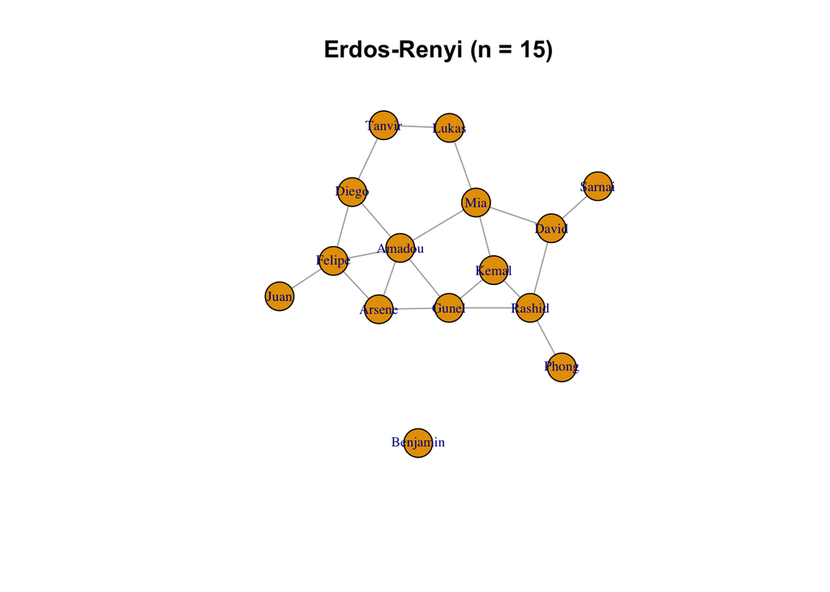

```r
plot(g_er, vertex.size = 18, vertex.label.cex = 0.7, main = "Erdos-Renyi (n = 15)")
```

**Example — Barabási–Albert (scale-free)**

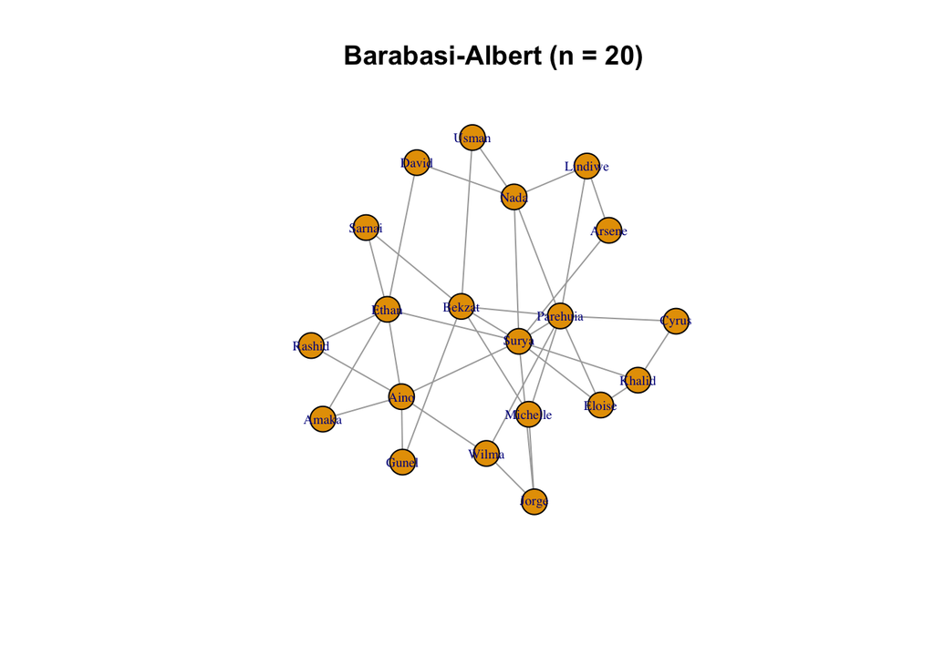

```r
g_ba <- simulate_igraph(n = 20, model = "ba", m_ba = 2, seed = 42)
plot(g_ba, vertex.size = 14, vertex.label.cex = 0.6, main = "Barabasi-Albert (n = 20)")
```

**Example — Watts–Strogatz (small-world)**

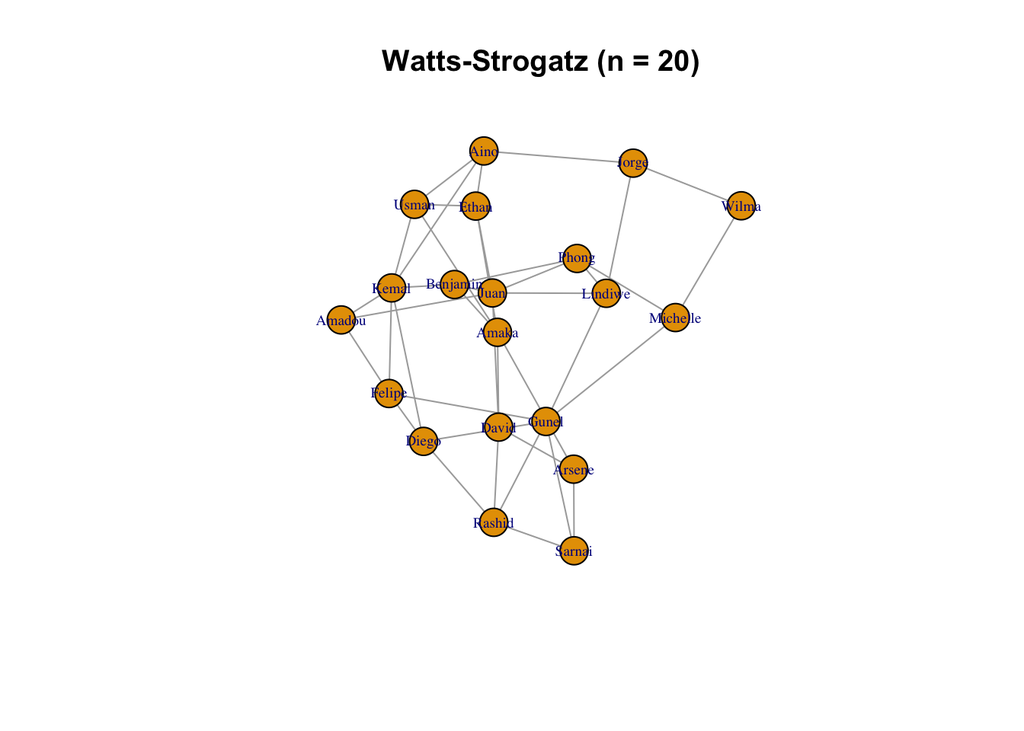

```r
g_ws <- simulate_igraph(n = 20, model = "ws", nei = 2, p_rewire = 0.1, seed = 42)
plot(g_ws, vertex.size = 14, vertex.label.cex = 0.6, main = "Watts-Strogatz (n = 20)")
```

## `simulate_network()`

Create a statnet `network` object (same model menu as `simulate_igraph()`) with named vertices and optional edge weights.

**Signature**

```r
args(simulate_network)
```

```
#> function (n = NULL, model = c("er", "ba", "ws", "sbm", "reg",
#>     "grg", "ff"), name_source = c("human", "states"), regions = "all",
#>     categories = "all", names = NULL, directed = FALSE, weighted = FALSE,
#>     weights = c(0.1, 1), p = 0.1, m = NULL, power = 1, m_ba = 2,
#>     nei = 2, p_rewire = 0.05, blocks = 3, p_within = 0.3, p_between = 0.05,
#>     k = 4, radius = 0.25, fw = 0.35, bw = 0.32, seed = NULL)
#> NULL
```

**Example**

```r
net <- simulate_network(n = 15, model = "er", seed = 42)
net
```

```
#>  Network attributes:
#>   vertices = 15
#>   directed = FALSE
#>   hyper = FALSE
#>   loops = FALSE
#>   multiple = FALSE
#>   bipartite = FALSE
#>   total edges= 12
#>     missing edges= 0
#>     non-missing edges= 12
#>
#>  Vertex attribute names:
#>     vertex.names
#>
#> No edge attributes
```

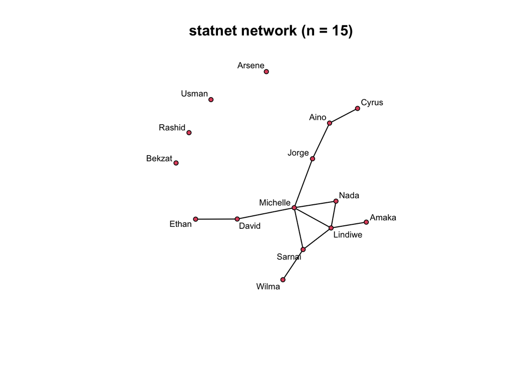

```r
plot(net, displaylabels = TRUE, label.cex = 0.7, main = "statnet network (n = 15)")
```

## `simulate_edge_list()`

Generate a directed/undirected weighted edge list for social-network analysis, with each node assigned to one of several classes.

**Signature**

```r
args(simulate_edge_list)
```

```
#> function (n_nodes = 20, n_edges = NULL, edge_density = 3, n_classes = 3,
#>     directed = TRUE, allow_self_loops = FALSE, weight_range = c(0.1,
#>         1), names = NULL, class_probs = NULL, seed = NULL)
#> NULL
```

**Example**

```r
edges <- simulate_edge_list(n_nodes = 12, n_classes = 3, seed = 42)
str(edges)
```

```
#> 'data.frame':    36 obs. of  4 variables:
#>  $ source: chr  "Anahera" "Anahera" "Cuauhtemoc" "Cuauhtemoc" ...
#>  $ target: chr  "Eloise" "Soraya" "Anahera" "Eloise" ...
#>  $ weight: num  0.31 0.364 0.913 0.421 0.631 ...
#>  $ class : int  3 2 2 1 1 3 2 3 3 1 ...
```

```r
head(edges)
```

|  | source | target | weight | class |
| --- | --- | --- | --- | --- |
| 1 | Anahera | Eloise | 0.3102 | 3 |
| 2 | Anahera | Soraya | 0.3643 | 2 |
| 3 | Cuauhtemoc | Anahera | 0.9133 | 2 |
| 4 | Cuauhtemoc | Eloise | 0.4210 | 1 |
| 5 | Cuauhtemoc | Soraya | 0.6307 | 1 |
| 6 | Eloise | Soraya | 0.8393 | 3 |

## `simulate_long_data()`

Generate hierarchical long-format sequence data (one row per actor-event) with Actor, Achiever, Group, Course, Time, and Action columns — the canonical format for educational-process mining.

**Signature**

```r
args(simulate_long_data)
```

```
#> function (n_groups = 5, n_actors = 10, n_courses = 3, n_states = 9,
#>     states = NULL, use_learning_states = TRUE, categories = "group_regulation",
#>     seq_length_range = c(10, 30), achiever_levels = c("High",
#>         "Low"), achiever_probs = c(0.5, 0.5), start_time = "2025-01-01 10:00:00",
#>     time_interval_range = c(60, 600), trans_matrix = NULL, init_probs = NULL,
#>     seed = NULL, actors_per_group = NULL, actions = NULL, action_categories = NULL,
#>     n_actions = NULL, transition_probs = NULL, initial_probs = NULL)
#> NULL
```

**Example**

```r
long <- simulate_long_data(n_groups = 3, n_actors = 2, seed = 42)
str(long)
```

```
#> tibble [138 × 6] (S3: tbl_df/tbl/data.frame)
#>  $ Actor   : num [1:138] 1 1 1 1 1 1 1 1 1 1 ...
#>  $ Achiever: chr [1:138] "High" "High" "High" "High" ...
#>  $ Group   : int [1:138] 1 1 1 1 1 1 1 1 1 1 ...
#>  $ Course  : chr [1:138] "A" "A" "A" "A" ...
#>  $ Time    : POSIXct[1:138], format: "2025-01-01 10:19:56" "2025-01-01 10:29:47" ...
#>  $ Action  : chr [1:138] "adapt" "consensus" "synthesis" "discuss" ...
```

```r
head(long)
```

| Actor | Achiever | Group | Course | Time | Action |
| --- | --- | --- | --- | --- | --- |
| 1 | High | 1 | A | 2025-01-01 10:19:56.805565 | adapt |
| 1 | High | 1 | A | 2025-01-01 10:29:47.441649 | consensus |
| 1 | High | 1 | A | 2025-01-01 10:33:44.709646 | synthesis |
| 1 | High | 1 | A | 2025-01-01 10:36:17.047697 | discuss |
| 1 | High | 1 | A | 2025-01-01 10:41:40.705340 | discuss |
| 1 | High | 1 | A | 2025-01-01 10:42:50.796543 | coregulate |

## `simulate_onehot_data()`

Generate the same hierarchical sequence structure as `simulate_long_data()` but with each state expanded into its own one-hot indicator column.

**Signature**

```r
args(simulate_onehot_data)
```

```
#> function (n_groups = 5, n_actors = 10, n_courses = 3, n_states = 9,
#>     states = NULL, use_learning_states = TRUE, categories = "group_regulation",
#>     seq_length_range = c(10, 30), achiever_levels = c("High",
#>         "Low"), achiever_probs = c(0.5, 0.5), start_time = "2025-01-01 10:00:00",
#>     time_interval_range = c(60, 600), trans_matrix = NULL, init_probs = NULL,
#>     sort_states = FALSE, state_prefix = "", seed = NULL, actors_per_group = NULL,
#>     actions = NULL, action_categories = NULL, n_actions = NULL,
#>     transition_probs = NULL, initial_probs = NULL)
#> NULL
```

**Example**

```r
onehot <- simulate_onehot_data(n_groups = 3, n_actors = 2, seed = 42)
dim(onehot)
```

```
#> [1] 138  14
```

```r
str(onehot, list.len = 12)
```

```
#> tibble [138 × 14] (S3: tbl_df/tbl/data.frame)
#>  $ Actor     : num [1:138] 1 1 1 1 1 1 1 1 1 1 ...
#>  $ Achiever  : chr [1:138] "High" "High" "High" "High" ...
#>  $ Group     : int [1:138] 1 1 1 1 1 1 1 1 1 1 ...
#>  $ Course    : chr [1:138] "A" "A" "A" "A" ...
#>  $ Time      : POSIXct[1:138], format: "2025-01-01 10:19:56" "2025-01-01 10:29:47" ...
#>  $ adapt     : int [1:138] 1 0 0 0 0 0 0 0 0 0 ...
#>  $ consensus : int [1:138] 0 1 0 0 0 0 0 0 0 0 ...
#>  $ synthesis : int [1:138] 0 0 1 0 0 0 1 1 1 1 ...
#>  $ discuss   : int [1:138] 0 0 0 1 1 0 0 0 0 0 ...
#>  $ coregulate: int [1:138] 0 0 0 0 0 1 0 0 0 0 ...
#>  $ monitor   : int [1:138] 0 0 0 0 0 0 0 0 0 0 ...
#>  $ cohesion  : int [1:138] 0 0 0 0 0 0 0 0 0 0 ...
#>   [list output truncated]
```

```r
head(onehot)
```

| Actor | Achiever | Group | Course | Time | adapt | consensus | synthesis | discuss | coregulate | monitor | cohesion | plan | emotion |
| --- | --- | --- | --- | --- | --- | --- | --- | --- | --- | --- | --- | --- | --- |
| 1 | High | 1 | A | 2025-01-01 10:19:56.805565 | 1 | 0 | 0 | 0 | 0 | 0 | 0 | 0 | 0 |
| 1 | High | 1 | A | 2025-01-01 10:29:47.441649 | 0 | 1 | 0 | 0 | 0 | 0 | 0 | 0 | 0 |
| 1 | High | 1 | A | 2025-01-01 10:33:44.709646 | 0 | 0 | 1 | 0 | 0 | 0 | 0 | 0 | 0 |
| 1 | High | 1 | A | 2025-01-01 10:36:17.047697 | 0 | 0 | 0 | 1 | 0 | 0 | 0 | 0 | 0 |
| 1 | High | 1 | A | 2025-01-01 10:41:40.705340 | 0 | 0 | 0 | 1 | 0 | 0 | 0 | 0 | 0 |
| 1 | High | 1 | A | 2025-01-01 10:42:50.796543 | 0 | 0 | 0 | 0 | 1 | 0 | 0 | 0 | 0 |